# Pooled 3-Cohort Neuropsych: Spontaneous Reversal (Class 2 Crude)

Minghui (Grace) Wang

2026-07-10

## 0.Overview

This notebook finds **spontaneous reversal of cognitive aging** using Class 2 (follow-up-as-time) models.

**Algorithm.** We use each participant-test combination that has at least 2 valid visits for that test. We take the observed score change from baseline to the first follow-up and turn it into a per-year (annualized) change, and compare it to the model-estimated change over the 5, 10, 15, and 20-year horizons. Every model change is computed directly from the fitted model at the participant’s exact baseline age (fixed effects only, `model.matrix %*% fixef`); we do not round the age to a grid.

For each horizon *h*, let `model_change` be the direction-adjusted model change, and `obs` be the direction-adjusted annualized observed change:

- If `model_change < 0` (expected decline): reversal when `obs > (-1) * model_change`.
- If `model_change > 0` (expected improvement): reversal when `obs > 2 * model_change`.
- If `model_change = 0` (no expected change): reversal when `obs > 0`.

For Trails tests (higher = worse), we flip the sign of both the observed change and the model change, so that positive always means improvement.

**Outputs.**

- **Table 4 (exclusive count)**: age-bin counts. Each participant-test combination is counted once, in the column for its maximum qualifying horizon.
- **Table 4 (cumulative count)**: age-bin counts. Each column counts everyone who qualifies at that horizon or higher.
- **Table 4 (cumulative percentage)**: the cumulative counts divided by N. This is the spontaneous reversal rate in each age bin.
- **Scatter plots**: annualized observed change vs baseline age, colored by the maximum reversal horizon. Restricted to baseline age 50 to 90, to match Table 4.

# 1. Setup

## 1.1 Output folders

```r
# Use the same 2-visit crude analysis sample as the fitted models.
SAMPLE <- "2visit"
covariates <- NULL
source("R/setup_analysis_sample.R")

model_tag <- if (SAMPLE == "2visit") "crude_2visit" else "crude"
dir_tag   <- if (SAMPLE == "2visit") "_2visit" else ""

class2_fits_file <- "pooled3_crude_2visit_class2_fits.rds"

plot_dir     <- paste0(
  "../output/plots/pooled3_05_spontaneous_reversal_class2_crude", dir_tag
)
table_dir    <- paste0(
  "../output/tables/pooled3_05_spontaneous_reversal_class2_crude", dir_tag
)
dir.create(plot_dir,     recursive = TRUE, showWarnings = FALSE)
dir.create(table_dir,    recursive = TRUE, showWarnings = FALSE)
```

## 1.2 Load saved Class 2 models

```r
model_rds_dir <- "../output/models"

class2_fits <- readRDS(file.path(model_rds_dir, class2_fits_file))

class2_fits_success <- class2_fits |>
  filter(fit_success)

cat(
  "Loaded", nrow(class2_fits_success),
  "successfully fitted Class 2 model strata\n"
)
```

```
## Loaded 28 successfully fitted Class 2 model strata
```

```r
class2_fits_success |>
  select(test, sex_label, n_obs, n_subjects, subject_random_slope_used) |>
  knitr::kable()
```

| test | sex_label | n_obs | n_subjects | subject_random_slope_used |
| --- | --- | --- | --- | --- |
| coding_correct | Women | 1800 | 874 | TRUE |
| coding_correct | Men | 1599 | 775 | TRUE |
| dsb | Women | 5683 | 2003 | TRUE |
| dsb | Men | 4186 | 1553 | TRUE |
| dsf | Women | 5789 | 2037 | TRUE |
| dsf | Men | 4260 | 1573 | TRUE |
| lmd | Women | 7244 | 2313 | TRUE |
| lmd | Men | 5537 | 1863 | TRUE |
| lmi | Women | 7298 | 2319 | TRUE |
| lmi | Men | 5570 | 1870 | TRUE |
| lmr | Women | 6164 | 1975 | TRUE |
| lmr | Men | 4715 | 1580 | TRUE |
| pasd | Women | 6009 | 1936 | TRUE |
| pasd | Men | 4612 | 1549 | TRUE |
| pasi | Women | 6715 | 2115 | TRUE |
| pasi | Men | 5063 | 1678 | TRUE |
| pasr | Women | 3419 | 1428 | TRUE |
| pasr | Men | 2663 | 1128 | TRUE |
| trailsa | Women | 6109 | 2027 | TRUE |
| trailsa | Men | 4925 | 1698 | TRUE |
| trailsb | Women | 5861 | 1968 | TRUE |
| trailsb | Men | 4769 | 1662 | TRUE |
| vrd | Women | 6988 | 2266 | TRUE |
| vrd | Men | 5471 | 1848 | TRUE |
| vri | Women | 7038 | 2275 | TRUE |
| vri | Men | 5514 | 1858 | TRUE |
| vrr | Women | 6702 | 2149 | TRUE |
| vrr | Men | 5150 | 1708 | TRUE |

## 1.3 Test dictionary and score direction

```r
test_dictionary <- make_pooled_test_dictionary(model_ready_pool) # defined in R/workbook_writers.R.
test_dictionary |> knitr::kable()
```

| test | test_label | xprize_subdomain | range |
| --- | --- | --- | --- |
| dsf | Digit Span Forward | Attention | 0-9 |
| dsb | Digit Span Backward | Executive Function & Processing | 0-8 |
| trailsb | Trail Making Test Part B | Executive Function & Processing | 0.32-10.00 minutes; maximum time set at 10 minutes |
| lmd | Logical Memory, delayed recall | Memory | 0-23 |
| lmi | Logical Memory, immediate recall | Memory | 0-23 |
| lmr | Logical Memory, recognition | Memory | 0-11 |
| pasd | Paired Associates, delayed recall | Memory | 0-10 |
| pasi | Paired Associates, immediate recall | Memory | 0-21 |
| pasr | Paired Associates, recognition | Memory | 0-10 |
| coding_correct | WAIS-IV Coding, total correct | Psychomotor | 0-119 |
| trailsa | Trail Making Test Part A | Psychomotor | 0.32-10.00 minutes; maximum time set at 10 minutes |
| vrd | Visual Reproductions, delayed recall | Visual Learning | 0-14 |
| vri | Visual Reproductions, immediate recall | Visual Learning | 0-14 |
| vrr | Visual Reproductions, recognition | Visual Learning | 0-14 |

Trails A and Trails B are scored as completion time (higher = worse). For these tests, both observed and model changes are sign-flipped so that positive always means improvement.

```r
# `higher_is_worse_tests` is defined in `R/spontaneous_reversal_functions.R`.

test_dictionary |>
  mutate(
    score_direction = if_else(test %in% higher_is_worse_tests, -1L, 1L),
    direction_note  = if_else(
      score_direction == -1L,
      "Higher is worse (completion time); sign-flipped",
      "Higher is better"
    )
  ) |>
  select(test, test_label, score_direction, direction_note) |>
  knitr::kable()
```

| test | test_label | score_direction | direction_note |
| --- | --- | --- | --- |
| dsf | Digit Span Forward | 1 | Higher is better |
| dsb | Digit Span Backward | 1 | Higher is better |
| trailsb | Trail Making Test Part B | -1 | Higher is worse (completion time); sign-flipped |
| lmd | Logical Memory, delayed recall | 1 | Higher is better |
| lmi | Logical Memory, immediate recall | 1 | Higher is better |
| lmr | Logical Memory, recognition | 1 | Higher is better |
| pasd | Paired Associates, delayed recall | 1 | Higher is better |
| pasi | Paired Associates, immediate recall | 1 | Higher is better |
| pasr | Paired Associates, recognition | 1 | Higher is better |
| coding_correct | WAIS-IV Coding, total correct | 1 | Higher is better |
| trailsa | Trail Making Test Part A | -1 | Higher is worse (completion time); sign-flipped |
| vrd | Visual Reproductions, delayed recall | 1 | Higher is better |
| vri | Visual Reproductions, immediate recall | 1 | Higher is better |
| vrr | Visual Reproductions, recognition | 1 | Higher is better |

# 2. Participant-level reversal classification

# 2.1. Observed change (baseline to first follow-up)

We use each participant-test combination that has at least 2 valid visits for that test. The annualized change is `(score_followup1 - score_baseline) / followup_years`. The observed-change table (and the follow-up summary below) keeps only baseline age 50 to 90, to match Table 4 and the scatter plots.

## 2.1.1 Compute per stratum

```r
# For each successfully fitted test × sex stratum, compute participant-level observed change from baseline to the first follow-up visit, then restrict to index baseline age 50-90.

# Input:
#   data = stratum-specific analysis data stored in class2_fits_success

# Output:
#   obs = a nested participant-level table with one row per participant-test combination (baseline age 50-90), including baseline age, follow-up interval, raw change, and annualized observed change.

class2_with_obs <- class2_fits_success |>
  mutate(
    obs = map(
      data,
      \(data_x) {
        data_x |>
          # defined in R/spontaneous_reversal_functions.R：
          compute_obs_change() |>
          restrict_reversal_baseline_age()
          # index baseline age 50-90 only, applied here so subject_obs, summaries, model changes, classification, Table 4, and plots all share the same sample.
      }
    )
  )

# Unnest stratum-specific observed-change tables into one participant-level table used for summaries and downstream reversal classification.
subject_obs <- class2_with_obs |>
  select(test, sex_label, obs) |>
  unnest(obs)

cat(
  "Observed change computed for",
  n_distinct(subject_obs$dbgap_subject_id),
  "unique subjects across",
  n_distinct(subject_obs$test), "tests\n"
)
```

```
## Observed change computed for 3495 unique subjects across 14 tests
```

## 2.1.2 Follow-up interval summary

```r
subject_obs |>
  group_by(test, sex_label) |>
  summarise(
    n = n(),
    median_fu_years = median(followup_years),
    iqr_lo = quantile(followup_years, 0.25),
    iqr_hi = quantile(followup_years, 0.75),
    min_nonzero_fu_years = if_else(
      any(followup_years > 0, na.rm = TRUE),
      min(followup_years[followup_years > 0], na.rm = TRUE),
      NA_real_
    ),
    max_fu_years = max(followup_years),
    .groups = "drop"
  ) |>
  knitr::kable(digits = 1)
```

| test | sex_label | n | median_fu_years | iqr_lo | iqr_hi | min_nonzero_fu_years | max_fu_years |
| --- | --- | --- | --- | --- | --- | --- | --- |
| coding_correct | Women | 561 | 5.2 | 4.1 | 6.0 | 1.0 | 8.8 |
| coding_correct | Men | 485 | 5.2 | 4.1 | 5.9 | 1.0 | 9.0 |
| dsb | Women | 1630 | 5.3 | 2.4 | 7.0 | 0.2 | 20.3 |
| dsb | Men | 1231 | 5.3 | 2.9 | 7.0 | 0.5 | 17.0 |
| dsf | Women | 1662 | 5.3 | 2.4 | 7.0 | 0.2 | 20.3 |
| dsf | Men | 1252 | 5.3 | 2.9 | 7.0 | 0.5 | 17.0 |
| lmd | Women | 1850 | 5.8 | 3.4 | 6.9 | 0.2 | 19.0 |
| lmd | Men | 1468 | 5.9 | 3.9 | 6.8 | 0.5 | 17.1 |
| lmi | Women | 1859 | 5.8 | 3.4 | 6.9 | 0.2 | 20.3 |
| lmi | Men | 1477 | 5.9 | 3.8 | 6.8 | 0.5 | 17.1 |
| lmr | Women | 1574 | 5.8 | 3.1 | 6.8 | 0.4 | 19.0 |
| lmr | Men | 1266 | 5.9 | 4.0 | 6.8 | 0.5 | 17.1 |
| pasd | Women | 1542 | 5.8 | 3.2 | 6.8 | 0.4 | 19.0 |
| pasd | Men | 1241 | 5.9 | 4.1 | 6.8 | 0.5 | 17.1 |
| pasi | Women | 1744 | 5.8 | 3.3 | 6.9 | 0.2 | 19.0 |
| pasi | Men | 1382 | 5.9 | 3.8 | 6.8 | 0.5 | 17.4 |
| pasr | Women | 1139 | 5.9 | 3.6 | 7.2 | 0.3 | 13.1 |
| pasr | Men | 898 | 5.8 | 4.3 | 7.2 | 0.7 | 12.0 |
| trailsa | Women | 1567 | 5.9 | 3.6 | 6.8 | 0.4 | 19.0 |
| trailsa | Men | 1301 | 5.9 | 4.1 | 6.8 | 0.5 | 18.0 |
| trailsb | Women | 1526 | 5.9 | 3.6 | 6.9 | 0.4 | 19.0 |
| trailsb | Men | 1275 | 5.9 | 4.1 | 6.8 | 0.5 | 18.0 |
| vrd | Women | 1803 | 5.9 | 3.5 | 6.9 | 0.2 | 19.0 |
| vrd | Men | 1450 | 5.9 | 3.9 | 6.8 | 0.5 | 17.1 |
| vri | Women | 1816 | 5.9 | 3.5 | 6.9 | 0.2 | 19.0 |
| vri | Men | 1460 | 5.9 | 3.9 | 6.8 | 0.5 | 17.1 |
| vrr | Women | 1747 | 5.8 | 3.4 | 6.9 | 0.2 | 19.0 |
| vrr | Men | 1393 | 5.9 | 3.9 | 6.8 | 0.5 | 17.1 |

# 2.2. Model-estimated changes (Class 2)

We compute the model-derived threshold directly from the fitted model, using fixed effects only (`model.matrix %*% fixef`). We do not read any value from Table 2.

Class 2 separates baseline age from follow-up time. For a participant indexed at baseline age *A* and horizon *h*, the **reference start age** is *A − h*. The threshold is the expected *h*-year aging change from the reference start age *A − h* up to age *A*. In Class 2 this is a follow-up change that starts from reference baseline age *A − h* and runs *h* years (the reference-start-age contrast):

```
Pred_Class2(baseline_age = A - h, t_followup = h)
- Pred_Class2(baseline_age = A - h, t_followup = 0)
```

This uses the same contrast structure as Table 2 for an *h*-year follow-up change starting from baseline age *A − h*, but we evaluate it directly from the fitted model at the participant’s exact age. We do not round to, or look up, the displayed 5-year Table 2 grid.

For example, if *A* = 72, the 5/10/15/20-year thresholds use:

- baseline_age = 67, `t_followup` 0 to 5
- baseline_age = 62, `t_followup` 0 to 10
- baseline_age = 57, `t_followup` 0 to 15
- baseline_age = 52, `t_followup` 0 to 20

Because we use the exact age, a 72.4-year-old uses reference start ages 67.4 / 62.4 / 57.4 / 52.4.

```r
## Compute per stratum
class2_with_mc <- class2_with_obs |>
  mutate(
    model_changes = pmap(
      list(model, obs),
      function(model_x, obs_x) {
        # model_x = test × sex fitted Class 2 model
        # obs_x   = test × sex observed-change participant table
        compute_model_change_class2(model_x, unique(obs_x$baseline_age)) # defined in R/spontaneous_reversal_functions.R.
        # unique(obs_x$baseline_age) = participant-specific observed baseline age
      }
    )
  )
```

# 2.3. Reversal classification

Join observed changes with model-estimated changes and apply the spontaneous reversal rule.

## 2.3.1 Classify

```r
# For each participant-test record, join observed change with exact-age model-estimated changes, then apply the reversal threshold rules.

reversal_subject_level <- class2_with_mc |>
  mutate(
    classified = pmap(
      list(obs, model_changes, test, sex_label),
      function(obs_x, mc_x, test_x, sex_x) {
        obs_x |>                                       # participant-level observed change
          left_join(mc_x, by = "baseline_age") |>      # exact-age model change
          mutate(test = test_x, sex_label = sex_x) |>
          classify_reversal()                          # defined in R/spontaneous_reversal_functions.R
      }
    )
  ) |>
  select(classified) |>
  unnest(classified) |>
  restrict_reversal_baseline_age()

cat(
  "Classified", nrow(reversal_subject_level),
  "participant-test combinations (baseline age 50-90) across",
  n_distinct(reversal_subject_level$test), "tests\n"
)
```

```
## Classified 39599 participant-test combinations (baseline age 50-90) across 14 tests
```

## 2.3.2 Reversal summary

```r
reversal_subject_level |>
  group_by(test, sex_label) |>
  summarise(
    n = n(),
    n_any_rev = sum(max_reversal_year > 0),
    pct_any = 100 * mean(max_reversal_year > 0),
    n_rev_5  = sum(reversal_5yr),
    n_rev_10 = sum(reversal_10yr),
    n_rev_15 = sum(reversal_15yr),
    n_rev_20 = sum(reversal_20yr),
    .groups = "drop"
  ) |>
  knitr::kable(digits = 1)
```

| test | sex_label | n | n_any_rev | pct_any | n_rev_5 | n_rev_10 | n_rev_15 | n_rev_20 |
| --- | --- | --- | --- | --- | --- | --- | --- | --- |
| coding_correct | Women | 561 | 6 | 1.1 | 6 | 0 | 0 | 0 |
| coding_correct | Men | 485 | 27 | 5.6 | 18 | 7 | 7 | 19 |
| dsb | Women | 1630 | 374 | 22.9 | 350 | 282 | 199 | 139 |
| dsb | Men | 1231 | 302 | 24.5 | 298 | 260 | 219 | 177 |
| dsf | Women | 1662 | 346 | 20.8 | 341 | 276 | 272 | 243 |
| dsf | Men | 1252 | 282 | 22.5 | 237 | 219 | 125 | 74 |
| lmd | Women | 1850 | 456 | 24.6 | 456 | 261 | 164 | 97 |
| lmd | Men | 1468 | 380 | 25.9 | 380 | 225 | 149 | 91 |
| lmi | Women | 1859 | 475 | 25.6 | 475 | 296 | 197 | 135 |
| lmi | Men | 1477 | 340 | 23.0 | 340 | 196 | 139 | 104 |
| lmr | Women | 1574 | 492 | 31.3 | 489 | 381 | 209 | 128 |
| lmr | Men | 1266 | 421 | 33.3 | 419 | 371 | 280 | 192 |
| pasd | Women | 1542 | 252 | 16.3 | 180 | 88 | 137 | 76 |
| pasd | Men | 1241 | 342 | 27.6 | 342 | 251 | 177 | 137 |
| pasi | Women | 1744 | 381 | 21.8 | 283 | 252 | 168 | 77 |
| pasi | Men | 1382 | 380 | 27.5 | 333 | 263 | 156 | 89 |
| pasr | Women | 1139 | 40 | 3.5 | 22 | 17 | 12 | 9 |
| pasr | Men | 898 | 55 | 6.1 | 52 | 35 | 30 | 28 |
| trailsa | Women | 1567 | 50 | 3.2 | 34 | 14 | 4 | 16 |
| trailsa | Men | 1301 | 84 | 6.5 | 30 | 4 | 28 | 29 |
| trailsb | Women | 1526 | 69 | 4.5 | 39 | 14 | 22 | 24 |
| trailsb | Men | 1275 | 43 | 3.4 | 24 | 14 | 23 | 17 |
| vrd | Women | 1803 | 357 | 19.8 | 357 | 177 | 90 | 46 |
| vrd | Men | 1450 | 401 | 27.7 | 395 | 262 | 150 | 87 |
| vri | Women | 1816 | 370 | 20.4 | 370 | 162 | 64 | 21 |
| vri | Men | 1460 | 373 | 25.5 | 356 | 251 | 212 | 147 |
| vrr | Women | 1747 | 416 | 23.8 | 414 | 335 | 262 | 165 |
| vrr | Men | 1393 | 327 | 23.5 | 327 | 233 | 176 | 154 |

# 3. Output table 4

The participant-level classifications were summarized by baseline-age group in exclusive, cumulative, and cumulative-percentage formats.

## 3.1 Table 4 (exclusive form)

```r
table4_exclusive <- make_table4(
  reversal_subject_level, test_dictionary, form = "exclusive"
)

# Preview one test.
table4_exclusive |>
  filter(test == "lmd") |>
  select(-xprize_subdomain, -test, -test_label, -age_bin) |>
  knitr::kable()
```

| sex_label | age_label | N | N reversal 5yr | N reversal 10yr | N reversal 15yr | N reversal 20yr |
| --- | --- | --- | --- | --- | --- | --- |
| Women | 50-54 | 342 | 34 | 2 | 1 | 0 |
| Women | 55-59 | 334 | 46 | 30 | 15 | 6 |
| Women | 60-64 | 251 | 4 | 19 | 45 | 46 |
| Women | 65-69 | 224 | 32 | 11 | 2 | 26 |
| Women | 70-74 | 201 | 31 | 5 | 2 | 5 |
| Women | 75-79 | 176 | 10 | 1 | 2 | 7 |
| Women | 80-84 | 186 | 20 | 18 | 5 | 5 |
| Women | 85-90 | 136 | 14 | 7 | 3 | 2 |
| Men | 50-54 | 277 | 22 | 2 | 1 | 0 |
| Men | 55-59 | 299 | 47 | 7 | 4 | 0 |
| Men | 60-64 | 220 | 25 | 44 | 19 | 5 |
| Men | 65-69 | 209 | 8 | 2 | 28 | 47 |
| Men | 70-74 | 203 | 21 | 9 | 4 | 19 |
| Men | 75-79 | 133 | 14 | 4 | 4 | 11 |
| Men | 80-84 | 81 | 5 | 4 | 2 | 6 |
| Men | 85-90 | 46 | 7 | 4 | 2 | 3 |

```r
# Save CSV (analysis) + formatted XLSX (delivery). write_table4_workbook() and
# make_output_name() are defined in workbook_writers.R / helpers.R.
write_csv(
  table4_exclusive,
  file.path(
    table_dir,
    make_output_name(
      paste0("xprize_pooled3_", model_tag, "_class2_table4_exclusive"),
      "csv"
    )
  )
)

table4_excl_xlsx <- file.path(
  table_dir,
  make_output_name(
    paste0("xprize_pooled3_", model_tag, "_class2_table4_exclusive"),
    "xlsx"
  )
)
write_table4_workbook(table4_exclusive, table4_excl_xlsx, form = "exclusive")
```

## 3.2 Table 4 (cumulative form)

```r
table4_cumulative <- make_table4(
  reversal_subject_level, test_dictionary, form = "cumulative"
)

# Preview one test.
table4_cumulative |>
  filter(test == "lmd") |>
  select(-xprize_subdomain, -test, -test_label, -age_bin) |>
  knitr::kable()
```

| sex_label | age_label | N | N reversal 5yr | N reversal 10yr | N reversal 15yr | N reversal 20yr |
| --- | --- | --- | --- | --- | --- | --- |
| Women | 50-54 | 342 | 37 | 3 | 1 | 0 |
| Women | 55-59 | 334 | 97 | 51 | 21 | 6 |
| Women | 60-64 | 251 | 114 | 110 | 91 | 46 |
| Women | 65-69 | 224 | 71 | 39 | 28 | 26 |
| Women | 70-74 | 201 | 43 | 12 | 7 | 5 |
| Women | 75-79 | 176 | 20 | 10 | 9 | 7 |
| Women | 80-84 | 186 | 48 | 28 | 10 | 5 |
| Women | 85-90 | 136 | 26 | 12 | 5 | 2 |
| Men | 50-54 | 277 | 25 | 3 | 1 | 0 |
| Men | 55-59 | 299 | 58 | 11 | 4 | 0 |
| Men | 60-64 | 220 | 93 | 68 | 24 | 5 |
| Men | 65-69 | 209 | 85 | 77 | 75 | 47 |
| Men | 70-74 | 203 | 53 | 32 | 23 | 19 |
| Men | 75-79 | 133 | 33 | 19 | 15 | 11 |
| Men | 80-84 | 81 | 17 | 12 | 8 | 6 |
| Men | 85-90 | 46 | 16 | 9 | 5 | 3 |

```r
write_csv(
  table4_cumulative,
  file.path(
    table_dir,
    make_output_name(
      paste0("xprize_pooled3_", model_tag, "_class2_table4_cumulative"),
      "csv"
    )
  )
)

table4_cumul_xlsx <- file.path(
  table_dir,
  make_output_name(
    paste0("xprize_pooled3_", model_tag, "_class2_table4_cumulative"),
    "xlsx"
  )
)
write_table4_workbook(table4_cumulative, table4_cumul_xlsx, form = "cumulative")
```

## 3.3 Table 4 (cumulative percentage)

```r
table4_cumulative_pct <- make_table4(
  reversal_subject_level, test_dictionary, form = "cumulative_pct"
)

# Preview one test (values are proportions of N).
table4_cumulative_pct |>
  filter(test == "lmd") |>
  select(-xprize_subdomain, -test, -test_label, -age_bin) |>
  knitr::kable(digits = 3)
```

| sex_label | age_label | N | N reversal 5yr | N reversal 10yr | N reversal 15yr | N reversal 20yr |
| --- | --- | --- | --- | --- | --- | --- |
| Women | 50-54 | 342 | 0.108 | 0.009 | 0.003 | 0.000 |
| Women | 55-59 | 334 | 0.290 | 0.153 | 0.063 | 0.018 |
| Women | 60-64 | 251 | 0.454 | 0.438 | 0.363 | 0.183 |
| Women | 65-69 | 224 | 0.317 | 0.174 | 0.125 | 0.116 |
| Women | 70-74 | 201 | 0.214 | 0.060 | 0.035 | 0.025 |
| Women | 75-79 | 176 | 0.114 | 0.057 | 0.051 | 0.040 |
| Women | 80-84 | 186 | 0.258 | 0.151 | 0.054 | 0.027 |
| Women | 85-90 | 136 | 0.191 | 0.088 | 0.037 | 0.015 |
| Men | 50-54 | 277 | 0.090 | 0.011 | 0.004 | 0.000 |
| Men | 55-59 | 299 | 0.194 | 0.037 | 0.013 | 0.000 |
| Men | 60-64 | 220 | 0.423 | 0.309 | 0.109 | 0.023 |
| Men | 65-69 | 209 | 0.407 | 0.368 | 0.359 | 0.225 |
| Men | 70-74 | 203 | 0.261 | 0.158 | 0.113 | 0.094 |
| Men | 75-79 | 133 | 0.248 | 0.143 | 0.113 | 0.083 |
| Men | 80-84 | 81 | 0.210 | 0.148 | 0.099 | 0.074 |
| Men | 85-90 | 46 | 0.348 | 0.196 | 0.109 | 0.065 |

```r
write_csv(
  table4_cumulative_pct,
  file.path(
    table_dir,
    make_output_name(
      paste0("xprize_pooled3_", model_tag, "_class2_table4_cumulative_pct"),
      "csv"
    )
  )
)

table4_cumul_pct_xlsx <- file.path(
  table_dir,
  make_output_name(
    paste0("xprize_pooled3_", model_tag, "_class2_table4_cumulative_pct"),
    "xlsx"
  )
)
write_table4_workbook(
  table4_cumulative_pct, table4_cumul_pct_xlsx, form = "cumulative_pct"
)
```

# 4. Scatter plots

Table 4 gives only age-bin counts. These scatter plots show the **participant-level data behind those counts**, so we can see *who* is called a reverser and why.

Each point is one participant-test record:

- **x** = baseline age. **y** = the direction-adjusted annualized observed change (positive = improvement, for every test, after the Trails sign-flip). This is the exact number the reversal rule compares to the model threshold.
- The dashed line at **y = 0** separates observed decline (below) from observed improvement (above).
- **Color** = the maximum reversal horizon each record reached. Grey = none, and the color gets darker from 5y to 20y. A longer horizon means the point cleared a higher threshold, so it is a more extreme apparent reversal.
- Panels are split by sex. The age axis is 50 to 90, to match Table 4.

Scatter plots display the participant-level observations underlying Table 4. The x-axis shows baseline age and the y-axis shows direction-adjusted annualized change. Points are colored by maximum qualifying reversal horizon and panels are separated by sex.

## 4.1 Check one test

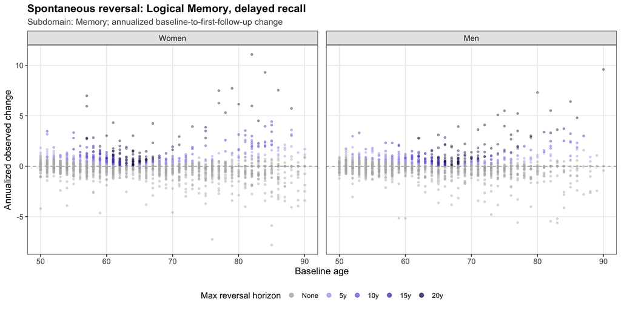

```r
# defined in spontaneous_reversal_functions.R
plot_reversal_scatter(reversal_subject_level, test_dictionary, "lmd")
```

## 4.2 Save all tests

```r
scatter_order <- reversal_subject_level |>
  distinct(test) |>
  left_join(
    test_dictionary |> select(test, xprize_subdomain),
    by = "test"
  ) |>
  arrange(xprize_subdomain, test)

walk2(
  scatter_order$xprize_subdomain,
  scatter_order$test,
  function(subdomain_x, test_x) {

    p <- plot_reversal_scatter(
      reversal_subject_level, test_dictionary, test_x
    )

    subdomain_file <- subdomain_x |>
      str_to_lower() |>
      str_replace_all("&", "and") |>
      str_replace_all("[^a-z0-9]+", "_") |>
      str_replace_all("_+", "_") |>
      str_replace_all("^_|_$", "")

    test_file <- test_x |>
      str_to_lower() |>
      str_replace_all("[^a-z0-9]+", "_") |>
      str_replace_all("_+", "_") |>
      str_replace_all("^_|_$", "")

    ggsave(
      filename = file.path(
        plot_dir,
        paste0(
          "class2_reversal_scatter_",
          subdomain_file, "_", test_file,
          "_", output_suffix, ".pdf"
        )
      ),
      plot = p,
      width = 12,
      height = 6
    )
  }
)

cat("Scatter plots saved to:", plot_dir, "\n")
```

```
## Scatter plots saved to: ../output/plots/pooled3_05_spontaneous_reversal_class2_crude_2visit
```